# BFAS_SF_ptwo

Christopher

2022-02-05

# Reanalysis of the Study 2 Raw Data

## Workflow

- **screen – see screening section**
- **compute competence**
- **What’s up with Sandia?** **Psychometrics, alt forms. (sandia axed)**
- **note the chosen SF items:**~~ *listed in the code chunk*
- **score the BFAS and CAS or LATS or whatever our SF gets to be named**~~
- **score relative imp, grips, sandia, auxvars**
- **Correlation matrices with:**
  - Big and Little
  - Importance and Little
  - Other stuff (GRIPS and small scales) and Little
  - basic reliability stuff
  - present better
- **compare with past results**
- **anything I’m missing?**
- **table focusing on difference (full minus short) correlations with aux vars**
- **upload what we have so far to osf, etc**

Compare it to the old correlations, though.

##Scoring Aux

## Scoring Notes:

domains are available as single items or relative importance (domain importance rating/sum of them), but nnote that there are multiple ways this is scored.

Able correlates with Able 2 at 0.75

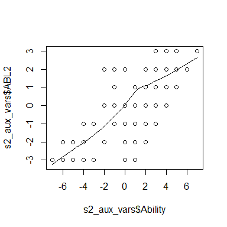

```r
scatter.smooth(s2_aux_vars$Ability, s2_aux_vars$ABL2)
```

```r
## domain relative importance -- just a check.
```

Self-reported ability items work well together for an index.

## Reversing BFAS, Scoring Full BFAS

```
##      [,1] [,2]
## [1,]    3    3
## [2,]    4    2
## [3,]    4    2
## [4,]    3    3
## [5,]    3    3
## [6,]    4    2
```

## Original conception of screening (pass/fail) rules

attn checks are: easy_attn & easy_attn2

select the center square (0), any other (1)

ABLE asks: are you more or less competent than average (more, average, less), if more (How much more competent? with an option including “less”) and vice versa.

- only 1 person failed to be consistent, but that’s a (0) and a (1) for everyone else.  
  We would also expect their answer to be consistent with Abl2, but we can skip it if I’m being picky  
  total of fail/pass attn checks should be ?

A look at all quality indexes, with all irrelevant block selections to be removed

### Filtering based on this more stringent requirement.

From the raw data, I have N= 333 with N = 305 fit for analyses. This is in contrast to 321 in the manuscript. The difference mainly comes from using all indices (one of which no one failed).

| easy_attn2 | box_attn | ableM_attn | ableL_attn | na_perc_attn |
| --- | --- | --- | --- | --- |
| 0 | 0 | 0 | NA | 0 |
| 0 | 0 | 0 | NA | 0 |
| 0 | 1 | NA | NA | 0 |
| 0 | 0 | NA | 0 | 0 |
| 0 | 0 | NA | NA | 0 |
| 0 | 0 | NA | NA | 0 |
| 0 | 0 | 0 | NA | 0 |
| 0 | 0 | 0 | NA | 0 |
| 0 | 0 | NA | NA | 0 |
| 0 | 0 | 0 | NA | 0 |

[output cut: 40 more lines]

| # failed | count |
| --- | --- |
| 0 | 305 |
| 1 | 27 |
| 2 | 1 |

```
## Some items ( Open_10 ) were negatively correlated with the total scale and
## probably should be reversed.
## To do this, run the function again with the 'check.keys=TRUE' option
```

```
## Some items ( Plt_1 ) were negatively correlated with the total scale and
## probably should be reversed.
## To do this, run the function again with the 'check.keys=TRUE' option
```

```
## Some items ( Open_2 Open_6 Open_8 Open_10 ) were negatively correlated with the total scale and
## probably should be reversed.
## To do this, run the function again with the 'check.keys=TRUE' option
```

Little BFAS with alphas

| row.names | alphas |
| --- | --- |
| Volatility | 0.9210192 |
| Withdrawal | 0.7710736 |
| Compassion | 0.7770809 |
| Politeness | 0.7571497 |
| Industriousness | 0.8935516 |
| Orderliness | 0.6832731 |
| Enthusiasm | 0.8529573 |
| Assitiveness | 0.7565850 |
| Intellect | 0.7377234 |
| Openness | 0.0969083 |

| row.names | alphas |
| --- | --- |
| Volatility | 0.8844111 |
| Withdrawal | 0.8851272 |
| Compassion | 0.8856426 |
| Politeness | 0.8138633 |
| Industriousness | 0.8882837 |
| Orderliness | 0.8059459 |
| Enthusiasm | 0.8631966 |
| Assitiveness | 0.8656882 |
| Intellect | 0.8584122 |
| Openness | -0.9725480 |

## Correlations Follow:

### Full form with Little Form

**I don’t like these style options, so let’s figure out better table formats**

BFAS with Little BFAS

| term | Volatility | Withdrawal | Compassion | Politeness | Industriousness | Orderliness | Enthusiasm | Assitiveness | Intellect | Openness | Volatility_L | Withdrawal_L | Compassion_L | Politeness_L | Industriousness_L | Orderliness_L | Enthusiasm_L | Assitiveness_L | Intellect_L | Openness_L |
| --- | --- | --- | --- | --- | --- | --- | --- | --- | --- | --- | --- | --- | --- | --- | --- | --- | --- | --- | --- | --- |
| Volatility | 1.00 | 0.76 | -0.38 | -0.44 | -0.64 | -0.17 | -0.43 | -0.35 | -0.60 | -0.24 | 0.91 | 0.72 | -0.16 | -0.50 | -0.64 | -0.09 | -0.45 | -0.25 | -0.60 | -0.53 |
| Withdrawal | 0.76 | 1.00 | -0.29 | -0.27 | -0.65 | -0.10 | -0.57 | -0.55 | -0.61 | -0.29 | 0.70 | 0.95 | -0.15 | -0.33 | -0.61 | 0.00 | -0.55 | -0.44 | -0.60 | -0.57 |
| Compassion | -0.38 | -0.29 | 1.00 | 0.59 | 0.47 | 0.18 | 0.53 | 0.13 | 0.55 | 0.18 | -0.46 | -0.28 | 0.76 | 0.62 | 0.46 | 0.07 | 0.54 | 0.01 | 0.55 | 0.40 |
| Politeness | -0.44 | -0.27 | 0.59 | 1.00 | 0.47 | 0.31 | 0.16 | -0.17 | 0.38 | 0.03 | -0.56 | -0.26 | 0.17 | 0.93 | 0.53 | 0.16 | 0.32 | -0.26 | 0.42 | 0.38 |
| Industriousness | -0.64 | -0.65 | 0.47 | 0.47 | 1.00 | 0.44 | 0.49 | 0.43 | 0.68 | 0.21 | -0.68 | -0.62 | 0.19 | 0.54 | 0.94 | 0.29 | 0.53 | 0.32 | 0.68 | 0.60 |
| Orderliness | -0.17 | -0.10 | 0.18 | 0.31 | 0.44 | 1.00 | 0.06 | 0.11 | 0.18 | 0.01 | -0.22 | -0.09 | 0.04 | 0.34 | 0.41 | 0.92 | 0.06 | 0.07 | 0.22 | 0.20 |
| Enthusiasm | -0.43 | -0.57 | 0.53 | 0.16 | 0.49 | 0.06 | 1.00 | 0.57 | 0.51 | 0.19 | -0.46 | -0.55 | 0.47 | 0.21 | 0.44 | 0.01 | 0.90 | 0.46 | 0.50 | 0.41 |
| Assitiveness | -0.35 | -0.55 | 0.13 | -0.17 | 0.43 | 0.11 | 0.57 | 1.00 | 0.43 | 0.23 | -0.30 | -0.51 | 0.17 | -0.06 | 0.33 | 0.10 | 0.43 | 0.92 | 0.41 | 0.38 |
| Intellect | -0.60 | -0.61 | 0.55 | 0.38 | 0.68 | 0.18 | 0.51 | 0.43 | 1.00 | 0.43 | -0.59 | -0.54 | 0.38 | 0.45 | 0.60 | 0.11 | 0.48 | 0.34 | 0.94 | 0.71 |
| Openness | -0.24 | -0.29 | 0.18 | 0.03 | 0.21 | 0.01 | 0.19 | 0.23 | 0.43 | 1.00 | -0.11 | -0.22 | 0.26 | 0.06 | 0.13 | 0.02 | 0.11 | 0.23 | 0.33 | 0.58 |
| Volatility_L | 0.91 | 0.70 | -0.46 | -0.56 | -0.68 | -0.22 | -0.46 | -0.30 | -0.59 | -0.11 | 1.00 | 0.68 | -0.10 | -0.63 | -0.73 | -0.08 | -0.56 | -0.17 | -0.64 | -0.53 |
| Withdrawal_L | 0.72 | 0.95 | -0.28 | -0.26 | -0.62 | -0.09 | -0.55 | -0.51 | -0.54 | -0.22 | 0.68 | 1.00 | -0.10 | -0.32 | -0.60 | 0.01 | -0.54 | -0.39 | -0.54 | -0.51 |
| Compassion_L | -0.16 | -0.15 | 0.76 | 0.17 | 0.19 | 0.04 | 0.47 | 0.17 | 0.38 | 0.26 | -0.10 | -0.10 | 1.00 | 0.15 | 0.08 | 0.05 | 0.31 | 0.14 | 0.32 | 0.19 |
| Politeness_L | -0.50 | -0.33 | 0.62 | 0.93 | 0.54 | 0.34 | 0.21 | -0.06 | 0.45 | 0.06 | -0.63 | -0.32 | 0.15 | 1.00 | 0.61 | 0.16 | 0.37 | -0.16 | 0.50 | 0.43 |
| Industriousness_L | -0.64 | -0.61 | 0.46 | 0.53 | 0.94 | 0.41 | 0.44 | 0.33 | 0.60 | 0.13 | -0.73 | -0.60 | 0.08 | 0.61 | 1.00 | 0.23 | 0.54 | 0.21 | 0.63 | 0.56 |
| Orderliness_L | -0.09 | 0.00 | 0.07 | 0.16 | 0.29 | 0.92 | 0.01 | 0.10 | 0.11 | 0.02 | -0.08 | 0.01 | 0.05 | 0.16 | 0.23 | 1.00 | -0.05 | 0.09 | 0.13 | 0.11 |
| Enthusiasm_L | -0.45 | -0.55 | 0.54 | 0.32 | 0.53 | 0.06 | 0.90 | 0.43 | 0.48 | 0.11 | -0.56 | -0.54 | 0.31 | 0.37 | 0.54 | -0.05 | 1.00 | 0.30 | 0.51 | 0.42 |
| Assitiveness_L | -0.25 | -0.44 | 0.01 | -0.26 | 0.32 | 0.07 | 0.46 | 0.92 | 0.34 | 0.23 | -0.17 | -0.39 | 0.14 | -0.16 | 0.21 | 0.09 | 0.30 | 1.00 | 0.32 | 0.29 |
| Intellect_L | -0.60 | -0.60 | 0.55 | 0.42 | 0.68 | 0.22 | 0.50 | 0.41 | 0.94 | 0.33 | -0.64 | -0.54 | 0.32 | 0.50 | 0.63 | 0.13 | 0.51 | 0.32 | 1.00 | 0.71 |
| Openness_L | -0.53 | -0.57 | 0.40 | 0.38 | 0.60 | 0.20 | 0.41 | 0.38 | 0.71 | 0.58 | -0.53 | -0.51 | 0.19 | 0.43 | 0.56 | 0.11 | 0.42 | 0.29 | 0.71 | 1.00 |

| term | Volatility_L | Withdrawal_L | Compassion_L | Politeness_L | Industriousness_L | Orderliness_L | Enthusiasm_L | Assitiveness_L | Intellect_L | Openness_L | rel_fam | rel_frnd | rel_fun | rel_poli | rel_wrk | rel_relig |
| --- | --- | --- | --- | --- | --- | --- | --- | --- | --- | --- | --- | --- | --- | --- | --- | --- |
| Volatility_L | NA | 0.68 | -0.10 | -0.63 | -0.73 | -0.08 | -0.56 | -0.17 | -0.64 | -0.53 | 0.23 | 0.14 | 0.18 | -0.08 | -0.08 | -0.24 |
| Withdrawal_L | 0.68 | NA | -0.10 | -0.32 | -0.60 | 0.01 | -0.54 | -0.39 | -0.54 | -0.51 | 0.08 | 0.10 | 0.08 | -0.02 | 0.00 | -0.16 |
| Compassion_L | -0.10 | -0.10 | NA | 0.15 | 0.08 | 0.05 | 0.31 | 0.14 | 0.32 | 0.19 | -0.06 | -0.18 | 0.00 | -0.01 | 0.12 | 0.08 |
| Politeness_L | -0.63 | -0.32 | 0.15 | NA | 0.61 | 0.16 | 0.37 | -0.16 | 0.50 | 0.43 | -0.33 | -0.11 | -0.31 | 0.04 | 0.19 | 0.32 |
| Industriousness_L | -0.73 | -0.60 | 0.08 | 0.61 | NA | 0.23 | 0.54 | 0.21 | 0.63 | 0.56 | -0.22 | -0.03 | -0.15 | 0.06 | 0.01 | 0.20 |
| Orderliness_L | -0.08 | 0.01 | 0.05 | 0.16 | 0.23 | NA | -0.05 | 0.09 | 0.13 | 0.11 | -0.06 | 0.16 | -0.09 | 0.09 | -0.11 | -0.01 |
| Enthusiasm_L | -0.56 | -0.54 | 0.31 | 0.37 | 0.54 | -0.05 | NA | 0.30 | 0.51 | 0.42 | -0.18 | -0.30 | -0.05 | 0.08 | 0.16 | 0.17 |
| Assitiveness_L | -0.17 | -0.39 | 0.14 | -0.16 | 0.21 | 0.09 | 0.30 | NA | 0.32 | 0.29 | 0.05 | 0.02 | 0.08 | 0.04 | -0.02 | -0.11 |
| Intellect_L | -0.64 | -0.54 | 0.32 | 0.50 | 0.63 | 0.13 | 0.51 | 0.32 | NA | 0.71 | -0.19 | -0.09 | -0.11 | -0.04 | 0.04 | 0.25 |
| Openness_L | -0.53 | -0.51 | 0.19 | 0.43 | 0.56 | 0.11 | 0.42 | 0.29 | 0.71 | NA | -0.14 | -0.12 | -0.12 | -0.03 | 0.03 | 0.25 |
| rel_fam | 0.23 | 0.08 | -0.06 | -0.33 | -0.22 | -0.06 | -0.18 | 0.05 | -0.19 | -0.14 | NA | -0.03 | -0.07 | -0.29 | -0.08 | -0.24 |
| rel_frnd | 0.14 | 0.10 | -0.18 | -0.11 | -0.03 | 0.16 | -0.30 | 0.02 | -0.09 | -0.12 | -0.03 | NA | 0.01 | -0.18 | -0.25 | -0.34 |
| rel_fun | 0.18 | 0.08 | 0.00 | -0.31 | -0.15 | -0.09 | -0.05 | 0.08 | -0.11 | -0.12 | -0.07 | 0.01 | NA | -0.11 | -0.18 | -0.45 |
| rel_poli | -0.08 | -0.02 | -0.01 | 0.04 | 0.06 | 0.09 | 0.08 | 0.04 | -0.04 | -0.03 | -0.29 | -0.18 | -0.11 | NA | -0.23 | -0.25 |
| rel_wrk | -0.08 | 0.00 | 0.12 | 0.19 | 0.01 | -0.11 | 0.16 | -0.02 | 0.04 | 0.03 | -0.08 | -0.25 | -0.18 | -0.23 | NA | -0.18 |
| rel_relig | -0.24 | -0.16 | 0.08 | 0.32 | 0.20 | -0.01 | 0.17 | -0.11 | 0.25 | 0.25 | -0.24 | -0.34 | -0.45 | -0.25 | -0.18 | NA |

Little BFAS with Absolute Importance

| term | Volatility_L | Withdrawal_L | Compassion_L | Politeness_L | Industriousness_L | Orderliness_L | Enthusiasm_L | Assitiveness_L | Intellect_L | Openness_L | imp_fam | imp_frnd | imp_fun | imp_poli | imp_wrk | imp_relig |
| --- | --- | --- | --- | --- | --- | --- | --- | --- | --- | --- | --- | --- | --- | --- | --- | --- |
| Volatility_L | NA | 0.68 | -0.10 | -0.63 | -0.73 | -0.08 | -0.56 | -0.17 | -0.64 | -0.53 | 0.18 | 0.10 | 0.17 | -0.06 | -0.07 | -0.20 |
| Withdrawal_L | 0.68 | NA | -0.10 | -0.32 | -0.60 | 0.01 | -0.54 | -0.39 | -0.54 | -0.51 | 0.11 | 0.13 | 0.12 | 0.06 | 0.07 | -0.09 |
| Compassion_L | -0.10 | -0.10 | NA | 0.15 | 0.08 | 0.05 | 0.31 | 0.14 | 0.32 | 0.19 | -0.28 | -0.38 | -0.22 | -0.22 | -0.12 | -0.13 |
| Politeness_L | -0.63 | -0.32 | 0.15 | NA | 0.61 | 0.16 | 0.37 | -0.16 | 0.50 | 0.43 | -0.20 | -0.01 | -0.22 | 0.11 | 0.23 | 0.33 |
| Industriousness_L | -0.73 | -0.60 | 0.08 | 0.61 | NA | 0.23 | 0.54 | 0.21 | 0.63 | 0.56 | -0.16 | -0.02 | -0.14 | 0.03 | -0.01 | 0.16 |
| Orderliness_L | -0.08 | 0.01 | 0.05 | 0.16 | 0.23 | NA | -0.05 | 0.09 | 0.13 | 0.11 | -0.11 | 0.09 | -0.14 | 0.02 | -0.14 | -0.06 |
| Enthusiasm_L | -0.56 | -0.54 | 0.31 | 0.37 | 0.54 | -0.05 | NA | 0.30 | 0.51 | 0.42 | -0.21 | -0.31 | -0.10 | -0.04 | 0.04 | 0.05 |
| Assitiveness_L | -0.17 | -0.39 | 0.14 | -0.16 | 0.21 | 0.09 | 0.30 | NA | 0.32 | 0.29 | -0.16 | -0.19 | -0.11 | -0.21 | -0.24 | -0.27 |
| Intellect_L | -0.64 | -0.54 | 0.32 | 0.50 | 0.63 | 0.13 | 0.51 | 0.32 | NA | 0.71 | -0.21 | -0.13 | -0.17 | -0.11 | -0.04 | 0.15 |
| Openness_L | -0.53 | -0.51 | 0.19 | 0.43 | 0.56 | 0.11 | 0.42 | 0.29 | 0.71 | NA | -0.17 | -0.15 | -0.16 | -0.09 | -0.04 | 0.14 |
| imp_fam | 0.18 | 0.11 | -0.28 | -0.20 | -0.16 | -0.11 | -0.21 | -0.16 | -0.21 | -0.17 | NA | 0.17 | 0.03 | -0.04 | 0.16 | 0.12 |
| imp_frnd | 0.10 | 0.13 | -0.38 | -0.01 | -0.02 | 0.09 | -0.31 | -0.19 | -0.13 | -0.15 | 0.17 | NA | 0.19 | 0.17 | 0.12 | 0.12 |
| imp_fun | 0.17 | 0.12 | -0.22 | -0.22 | -0.14 | -0.14 | -0.10 | -0.11 | -0.17 | -0.16 | 0.03 | 0.19 | NA | 0.11 | -0.02 | -0.10 |
| imp_poli | -0.06 | 0.06 | -0.22 | 0.11 | 0.03 | 0.02 | -0.04 | -0.21 | -0.11 | -0.09 | -0.04 | 0.17 | 0.11 | NA | 0.14 | 0.24 |
| imp_wrk | -0.07 | 0.07 | -0.12 | 0.23 | -0.01 | -0.14 | 0.04 | -0.24 | -0.04 | -0.04 | 0.16 | 0.12 | -0.02 | 0.14 | NA | 0.24 |
| imp_relig | -0.20 | -0.09 | -0.13 | 0.33 | 0.16 | -0.06 | 0.05 | -0.27 | 0.15 | 0.14 | 0.12 | 0.12 | -0.10 | 0.24 | 0.24 | NA |

Little BFAS with The Other Stuff

| term | Volatility_L | Withdrawal_L | Compassion_L | Politeness_L | Industriousness_L | Orderliness_L | Enthusiasm_L | Assitiveness_L | Intellect_L | Openness_L | Age | Edu | HHincome | POP | HOT | HLTH | SR_Competence |
| --- | --- | --- | --- | --- | --- | --- | --- | --- | --- | --- | --- | --- | --- | --- | --- | --- | --- |
| Volatility_L | NA | 0.68 | -0.10 | -0.63 | -0.73 | -0.08 | -0.56 | -0.17 | -0.64 | -0.53 | -0.11 | 0.18 | -0.09 | -0.05 | -0.13 | -0.16 | -0.12 |
| Withdrawal_L | 0.68 | NA | -0.10 | -0.32 | -0.60 | 0.01 | -0.54 | -0.39 | -0.54 | -0.51 | -0.17 | 0.02 | -0.18 | -0.21 | -0.26 | -0.30 | -0.26 |
| Compassion_L | -0.10 | -0.10 | NA | 0.15 | 0.08 | 0.05 | 0.31 | 0.14 | 0.32 | 0.19 | 0.08 | -0.01 | 0.02 | 0.21 | 0.17 | 0.17 | 0.19 |
| Politeness_L | -0.63 | -0.32 | 0.15 | NA | 0.61 | 0.16 | 0.37 | -0.16 | 0.50 | 0.43 | 0.22 | -0.34 | 0.02 | -0.29 | -0.17 | -0.09 | -0.19 |
| Industriousness_L | -0.73 | -0.60 | 0.08 | 0.61 | NA | 0.23 | 0.54 | 0.21 | 0.63 | 0.56 | 0.18 | -0.20 | 0.12 | -0.04 | 0.11 | 0.15 | 0.07 |
| Orderliness_L | -0.08 | 0.01 | 0.05 | 0.16 | 0.23 | NA | -0.05 | 0.09 | 0.13 | 0.11 | 0.02 | -0.07 | 0.07 | 0.00 | 0.05 | 0.12 | -0.01 |
| Enthusiasm_L | -0.56 | -0.54 | 0.31 | 0.37 | 0.54 | -0.05 | NA | 0.30 | 0.51 | 0.42 | 0.15 | -0.09 | 0.14 | 0.15 | 0.09 | 0.17 | 0.12 |
| Assitiveness_L | -0.17 | -0.39 | 0.14 | -0.16 | 0.21 | 0.09 | 0.30 | NA | 0.32 | 0.29 | -0.04 | 0.16 | 0.26 | 0.45 | 0.39 | 0.33 | 0.39 |
| Intellect_L | -0.64 | -0.54 | 0.32 | 0.50 | 0.63 | 0.13 | 0.51 | 0.32 | NA | 0.71 | 0.14 | -0.08 | 0.11 | 0.10 | 0.18 | 0.19 | 0.26 |
| Openness_L | -0.53 | -0.51 | 0.19 | 0.43 | 0.56 | 0.11 | 0.42 | 0.29 | 0.71 | NA | 0.14 | -0.10 | 0.15 | 0.10 | 0.15 | 0.17 | 0.18 |
| Age | -0.11 | -0.17 | 0.08 | 0.22 | 0.18 | 0.02 | 0.15 | -0.04 | 0.14 | 0.14 | NA | -0.06 | 0.04 | 0.03 | -0.13 | -0.06 | -0.06 |
| Edu | 0.18 | 0.02 | -0.01 | -0.34 | -0.20 | -0.07 | -0.09 | 0.16 | -0.08 | -0.10 | -0.06 | NA | 0.23 | 0.22 | 0.21 | 0.25 | 0.27 |
| HHincome | -0.09 | -0.18 | 0.02 | 0.02 | 0.12 | 0.07 | 0.14 | 0.26 | 0.11 | 0.15 | 0.04 | 0.23 | NA | 0.17 | 0.12 | 0.21 | 0.17 |
| POP | -0.05 | -0.21 | 0.21 | -0.29 | -0.04 | 0.00 | 0.15 | 0.45 | 0.10 | 0.10 | 0.03 | 0.22 | 0.17 | NA | 0.61 | 0.41 | 0.50 |
| HOT | -0.13 | -0.26 | 0.17 | -0.17 | 0.11 | 0.05 | 0.09 | 0.39 | 0.18 | 0.15 | -0.13 | 0.21 | 0.12 | 0.61 | NA | 0.58 | 0.43 |
| HLTH | -0.16 | -0.30 | 0.17 | -0.09 | 0.15 | 0.12 | 0.17 | 0.33 | 0.19 | 0.17 | -0.06 | 0.25 | 0.21 | 0.41 | 0.58 | NA | 0.41 |
| SR_Competence | -0.12 | -0.26 | 0.19 | -0.19 | 0.07 | -0.01 | 0.12 | 0.39 | 0.26 | 0.18 | -0.06 | 0.27 | 0.17 | 0.50 | 0.43 | 0.41 | NA |

## Code Appendix

```r
knitr::opts_chunk$set(fig.width=12, fig.height=8, echo=FALSE, warning=FALSE, message=FALSE)


library(tidyverse, quietly = TRUE)
library(magrittr, quietly = TRUE)
library(sjmisc, quietly = TRUE)
library(corrr, quietly = TRUE)
library(knitr, quietly = TRUE)
library(kableExtra, quietly = TRUE)
library(reactable, quietly = TRUE)


s2_possible_attn <- read_csv("Study2Data_manip.csv") %>%
  select(ResponseId, easy_attn, easy_attn2, Chk1_1:Less,ABL2, total_na)

s2_bfas <- read_csv("Study2Data_manip.csv") %>%
  select(ResponseId, Vol_1:Plt_10, Ind_1:Asrt_10, Ord_1:Ord_10,Enth_1:Asrt_10, Intel_1:Open_10) %>% select(-HAP_1, -HLTH)

s2_aux_vars <- read_csv("Study2Data_manip.csv") %>%
  select(ResponseId,Age, Race, Edu, GEN, HHincome, ABLE:Less, ABL2, POP, HOT, HLTH,
         starts_with("GRP"), starts_with("IMP")) %>%
  rename(imp_fam = IMP_1, imp_frnd = IMP_2, imp_fun =  IMP_3, imp_poli =IMP_4, imp_wrk = IMP_5, imp_relig = IMP_6)


##ability
s2_aux_vars %>% sjmisc::set_na(., More, na = -99) ->  s2_aux_vars
s2_aux_vars$Ability <- rowSums(s2_aux_vars[, c(8:10)], na.rm = TRUE)
s2_aux_vars$SR_Competence <- s2_aux_vars$Ability +  s2_aux_vars$ABL2
s2_aux_vars <- s2_aux_vars %>% row_means(., contains("GRP"),
                         n = 4, append = TRUE, var = "Risk_Pref")

##dumb rev code fxn
domain_rev_code <- function(x, na.rm = FALSE){
  (5-x)
}


## domain relative importance
domains_df <- s2_aux_vars  %>% select(imp_fam:imp_relig) %>% mutate_all(., domain_rev_code)
domains_df <- domains_df %>% row_sums(., contains("imp"),
                         n = 2, append = TRUE, var = "Imp_Tot")
domains_df <- domains_df %>% rowwise() %>% mutate(., rel_fam = imp_fam/Imp_Tot) %>%
  mutate(., rel_frnd = imp_frnd/Imp_Tot) %>% mutate(., rel_fun = imp_fun/Imp_Tot) %>%
  mutate(., rel_poli = imp_poli/Imp_Tot) %>% mutate(., rel_wrk = imp_wrk/Imp_Tot) %>%
  mutate(., rel_relig = imp_relig/Imp_Tot)

scatter.smooth(s2_aux_vars$Ability, s2_aux_vars$ABL2)
## domain relative importance -- just a check.


## These are the reversed items in the full BFAS

rev_bfas <- c("Vol_2", "Vol_4", "Vol_6", "Vol_8", "With_1", "With_3", "With_5", "With_8", "Comp_1", "Comp_4", "Comp_6", "Comp_7", "Comp_9", "Plt_2", "Plt_4", "Plt_7", "Plt_8", "Plt_9", "Plt_10", "Ind_2", "Ind_3", "Ind_4", "Ind_6", "Ind_9", "Ind_10", "Ord_1", "Ord_5", "Ord_7", "Ord_8", "Enth_2", "Enth_3", "Enth_4", "Enth_6", "Enth_7", "Asrt_3", "Asrt_5", "Asrt_8", "Asrt_10", "Intel_2", "Intel_5", "Intel_6", "Intel_9", "Open_5", "Open_8", "Open_9", "Open_10")

s2_bfas_rec <- s2_bfas  %>% modify_at(., .at = rev_bfas, ~6-.x)
head(cbind(s2_bfas$Open_10, s2_bfas_rec$Open_10))
## note -- I thought there were missing oppenness chunks?


#rm(s2_bfas)

## SCORING

s2_bfas_rec <- s2_bfas_rec %>% row_means(., contains("Vol"),
                         n = 5, append = TRUE, var = "Volatility")
s2_bfas_rec <- s2_bfas_rec %>% row_means(., contains("With"),
                         n = 5, append = TRUE, var = "Withdrawal")
s2_bfas_rec <- s2_bfas_rec %>% row_means(., contains("Comp"),
                         n = 5, append = TRUE, var = "Compassion")
s2_bfas_rec <- s2_bfas_rec %>% row_means(., contains("Plt"),
                         n = 5, append = TRUE, var = "Politeness")
s2_bfas_rec <- s2_bfas_rec %>% row_means(., contains("Ind"),
                         n = 5, append = TRUE, var = "Industriousness")
s2_bfas_rec <- s2_bfas_rec %>% row_means(., contains("Ord"),
                         n = 5, append = TRUE, var = "Orderliness")
s2_bfas_rec <- s2_bfas_rec %>% row_means(., contains("Enth"),
                         n = 5, append = TRUE, var = "Enthusiasm")
s2_bfas_rec <- s2_bfas_rec %>% row_means(., contains("Asrt"),
                         n = 5, append = TRUE, var = "Assitiveness")
s2_bfas_rec <- s2_bfas_rec %>% row_means(., contains("Intel"),
                         n = 5, append = TRUE, var = "Intellect")
s2_bfas_rec <- s2_bfas_rec %>% row_means(., contains("Open"),
                         n = 5, append = TRUE, var = "Openness")

LATS <- c("Vol_1", "Vol_3", "Vol_9", "Vol_10", "With_2", "With_5", "With_6", "With_10", "Comp_2", "Comp_3", "Comp_8", "Comp_10", "Plt_2", "Plt_6", "Plt_7", "Plt_8", "Ind_2", "Ind_3", "Ind_4", "Ind_10", "Ord_2", "Ord_3", "Ord_6", "Ord_7", "Enth_2", "Enth_3", "Enth_4", "Enth_7", "Asrt_1", "Asrt_2", "Asrt_5", "Asrt_6", "Intel_1", "Intel_2", "Intel_3", "Intel_6", "Open_1", "Open_3", "Open_9", "Open_10")

## because apparently this is what dplyr needs
s2_LATS <- s2_bfas_rec %>% select(all_of(LATS))

## SCORING

s2_LATS <- s2_LATS %>% row_means(., contains("Vol"),
                                 n = 2, append = TRUE, var = "Volatility_L") %>%
  row_means(., contains("With"), n = 2, append = TRUE, var = "Withdrawal_L") %>%
  row_means(., contains("Comp"), n = 2, append = TRUE, var = "Compassion_L") %>%
  row_means(., contains("Plt"),  n = 2, append = TRUE, var = "Politeness_L") %>%
  row_means(., contains("Ind"),n = 2,append = TRUE,var = "Industriousness_L") %>%
  row_means(., contains("Ord"), n = 2, append = TRUE, var = "Orderliness_L") %>%
  row_means(., contains("Enth"), n = 2, append = TRUE, var = "Enthusiasm_L") %>%
  row_means(., contains("Asrt"), n = 2, append = TRUE, var = "Assitiveness_L") %>%
  row_means(., contains("Intel"), n = 2, append = TRUE, var = "Intellect_L") %>%
  row_means(., contains("Open"), n = 2, append = TRUE, var = "Openness_L")


##cleaning it up

s2_possible_attn$box_attn <- if_else(s2_possible_attn$Chk1_1 == "On",  0, 1)
s2_possible_attn$ableM_attn <- if_else(s2_possible_attn$More == -99,  1, 0)
s2_possible_attn$ableL_attn <- if_else(s2_possible_attn$Less == -99,  1, 0)
s2_possible_attn$na_perc_attn <- if_else(s2_possible_attn$total_na >36, 1, 0)
s2_possible_attn <- s2_possible_attn[, -c(5:12)]
s2_possible_attn %>% select(easy_attn2, box_attn:na_perc_attn) -> s2_likely_attn
rmarkdown::paged_table(s2_likely_attn[1:50,])
attn_fail_tot <-  as.matrix(rowSums(s2_likely_attn, na.rm = TRUE))
table(as.factor(attn_fail_tot)) %>% as.data.frame() %>%
  knitr::kable(., "html", col.names = c("# failed", "count"))

## cleaning it up end

## creating our frame of useable scores (not included are demographics)
#####
scores <- bind_cols(s2_bfas_rec[,102:111], s2_LATS[, 41:50], s2_aux_vars[,c(2,4, 6, 11:13,29, 30)], domains_df[ , -7],  as.data.frame(attn_fail_tot))
scores <- scores %>% filter(V1 == 0) %>% select(-V1)
lats_alphas <- tibble(.rows = 10, row.names = names(s2_bfas_rec[,102:111]))
lats_alphas$alphas <- rep(0, 10)
s2_LATS  %>%  select(Vol_1:Vol_10) %>%
  psych::alpha() -> y;y$total[1] -> lats_alphas[1,"alphas"]
s2_LATS  %>%  select(With_2:With_10) %>%
  psych::alpha() -> y;y$total[1] -> lats_alphas[2,"alphas"]
s2_LATS  %>%  select(Comp_2:Comp_10) %>%
  psych::alpha() -> y;y$total[1] -> lats_alphas[3,"alphas"]
s2_LATS  %>%  select(Plt_2:Plt_8) %>%
  psych::alpha() -> y;y$total[1] -> lats_alphas[4,"alphas"]
s2_LATS  %>%  select(Ind_2:Ind_10) %>%
  psych::alpha() -> y;y$total[1] -> lats_alphas[5,"alphas"]
s2_LATS  %>%  select(Ord_2:Ord_7) %>%
  psych::alpha() -> y;y$total[1] -> lats_alphas[6,"alphas"]
s2_LATS  %>%  select(Enth_2:Enth_7) %>%
  psych::alpha() -> y;y$total[1] -> lats_alphas[7,"alphas"]
s2_LATS  %>%  select(Asrt_1:Asrt_6) %>%
  psych::alpha() -> y;y$total[1] -> lats_alphas[8,"alphas"]
s2_LATS  %>%  select(Intel_1:Intel_6) %>%
  psych::alpha()-> y;y$total[1] -> lats_alphas[9,"alphas"]
s2_LATS  %>%  select(Open_1:Open_10) %>%
  psych::alpha() -> y;y$total[1] -> lats_alphas[10,"alphas"]

full_alphas <- tibble(.rows = 10, row.names = names(s2_bfas_rec[,102:111]))
full_alphas$alphas <- rep(0, 10)
s2_bfas_rec  %>%  select(Vol_1:Vol_10) %>%
  psych::alpha() -> y;y$total[1] -> full_alphas[1,"alphas"]
s2_bfas_rec  %>%  select(With_1:With_10) %>%
  psych::alpha() -> y;y$total[1] -> full_alphas[2,"alphas"]
s2_bfas_rec  %>%  select(Comp_1:Comp_10) %>%
  psych::alpha() -> y;y$total[1] -> full_alphas[3,"alphas"]
s2_bfas_rec  %>%  select(Plt_1:Plt_10) %>%
  psych::alpha() -> y;y$total[1] -> full_alphas[4,"alphas"]
s2_bfas_rec  %>%  select(Ind_1:Ind_10) %>%
  psych::alpha() -> y;y$total[1] -> full_alphas[5,"alphas"]
s2_bfas_rec  %>%  select(Ord_1:Ord_10) %>%
  psych::alpha() -> y;y$total[1] -> full_alphas[6,"alphas"]
s2_bfas_rec  %>%  select(Enth_1:Enth_10) %>%
  psych::alpha() -> y;y$total[1] -> full_alphas[7,"alphas"]
s2_bfas_rec  %>%  select(Asrt_1:Asrt_10) %>%
  psych::alpha() -> y;y$total[1] -> full_alphas[8,"alphas"]
s2_bfas_rec  %>%  select(Intel_1:Intel_10) %>%
  psych::alpha()-> y;y$total[1] -> full_alphas[9,"alphas"]
s2_bfas_rec  %>%  select(Open_1:Open_10) %>%
  psych::alpha() -> y;y$total[1] -> full_alphas[10,"alphas"]
s2_bfas_rec %>% select(Volatility:Openness) %>% corrr::correlate() %>% shave -> BFAS_cormat
s2_LATS %>% select(Volatility_L:Openness_L) %>% corrr::correlate() %>% shave -> LATS_cormat
scores %>% dplyr::select(Volatility_L:Openness_L)  -> LATS_scores
scores %>% dplyr::select(Volatility:Openness) -> BFAS_scores
scores %>% dplyr::select(Volatility:Openness_L) -> LATS_BFAS_scores

lats_alphas %>% kbl(caption = "Little BFAS with alphas") %>%
  kable_styling(full_width = F, bootstrap_options = "condensed", html_font = 'Fira Mono' )
full_alphas %>% kbl(caption = "Little BFAS with alphas") %>%
  kable_styling(full_width = F, bootstrap_options = "condensed", html_font = 'Fira Mono' )

## correlation matrix
scores %>% select(Volatility:Openness_L) %>% correlate(., diagonal = 1) %>% round_num(., digits = 2) -> dom_asp_cormat


## correlation matrix
dom_asp_cormat  %>%
  kbl(caption = "BFAS with Little BFAS") %>%
  kable_styling(full_width = F, bootstrap_options = "condensed", html_font = 'Fira Mono') %>%
  scroll_box(width = "750px", height = "100%")



## build
scores %>% select(Volatility_L:Openness_L,rel_fam:rel_relig) %>%
  correlate() %>% round_num(., digits = 2) -> life_1_cor
scores %>% select(Volatility_L:Openness_L,imp_fam:imp_relig) %>%
  correlate() %>% round_num(., digits = 2)  -> life_2_cor

## correlation matrix

life_1_cor  %>%
  kbl(caption = "Abs Importance  with Little BFAS") %>%
  kable_styling(full_width = F, bootstrap_options = "condensed", html_font = 'Fira Mono') %>%   scroll_box(width = "750px", height = "100%")


## correlation matrix

life_2_cor  %>%
  kbl(caption = "Little BFAS with Absolute Importance") %>%
  kable_styling(full_width = F, bootstrap_options = "condensed", html_font = 'Fira Mono', ) %>%
  scroll_box(width = "750px", height = "100%")
## correlation matrix

scores %>% select(Volatility_L:Openness_L, Age:SR_Competence) %>% correlate() %>%
        sjmisc::round_num(., digits = 2) -> remains_cor
remains_cor  %>%
  kbl(caption = "Little BFAS with The Other Stuff") %>%
  kable_styling(full_width = F, bootstrap_options = "condensed", html_font = 'Fira Mono', ) %>%
  scroll_box(width = "750px", height = "100%")
```